# Project: Train a Quadcopter How to Fly

Design an agent to fly a quadcopter, and then train it using a reinforcement learning algorithm of your choice!

Try to apply the techniques you have learnt, but also feel free to come up with innovative ideas and test them.

## Instructions

Take a look at the files in the directory to better understand the structure of the project.

- `task.py`: Define your task (environment) in this file.
- `agents/`: Folder containing reinforcement learning agents.
  - `policy_search.py`: A sample agent has been provided here.
  - `agent.py`: Develop your agent here.
- `physics_sim.py`: This file contains the simulator for the quadcopter. **DO NOT MODIFY THIS FILE**.

For this project, you will define your own task in `task.py`. Although we have provided a example task to get you started, you are encouraged to change it. Later in this notebook, you will learn more about how to amend this file.

You will also design a reinforcement learning agent in `agent.py` to complete your chosen task.

You are welcome to create any additional files to help you to organize your code. For instance, you may find it useful to define a `model.py` file defining any needed neural network architectures.

## Controlling the Quadcopter

We provide a sample agent in the code cell below to show you how to use the sim to control the quadcopter. This agent is even simpler than the sample agent that you'll examine (in `agents/policy_search.py`) later in this notebook!

The agent controls the quadcopter by setting the revolutions per second on each of its four rotors. The provided agent in the `Basic_Agent` class below always selects a random action for each of the four rotors. These four speeds are returned by the `act` method as a list of four floating-point numbers.

For this project, the agent that you will implement in `agents/agent.py` will have a far more intelligent method for selecting actions!

```python
import random

class Basic_Agent():
    def __init__(self, task):
        self.task = task

    def act(self):
        new_thrust = random.gauss(450., 25.)
        return [new_thrust + random.gauss(0., 1.) for x in range(4)]
```

Run the code cell below to have the agent select actions to control the quadcopter.

Feel free to change the provided values of `runtime`, `init_pose`, `init_velocities`, and `init_angle_velocities` below to change the starting conditions of the quadcopter.

The `labels` list below annotates statistics that are saved while running the simulation. All of this information is saved in a text file `data.txt` and stored in the dictionary `results`.

```python
%load_ext autoreload
%autoreload 2

import csv
import numpy as np
from task import Task

# Modify the values below to give the quadcopter a different starting position.
runtime = 5.                                     # time limit of the episode
init_pose = np.array([0., 0., 10., 0., 0., 0.])  # initial pose
init_velocities = np.array([0., 0., 0.])         # initial velocities
init_angle_velocities = np.array([0., 0., 0.])   # initial angle velocities
file_output = 'data.txt'                         # file name for saved results

# Setup
task = Task(init_pose, init_velocities, init_angle_velocities, runtime)
agent = Basic_Agent(task)
done = False
labels = ['time', 'x', 'y', 'z', 'phi', 'theta', 'psi', 'x_velocity',
          'y_velocity', 'z_velocity', 'phi_velocity', 'theta_velocity',
          'psi_velocity', 'rotor_speed1', 'rotor_speed2', 'rotor_speed3', 'rotor_speed4']
results = {x : [] for x in labels}

# Run the simulation, and save the results.
with open(file_output, 'w') as csvfile:
    writer = csv.writer(csvfile)
    writer.writerow(labels)
    while True:
        rotor_speeds = agent.act()
        _, _, done = task.step(rotor_speeds)
        to_write = [task.sim.time] + list(task.sim.pose) + list(task.sim.v) + list(task.sim.angular_v) + list(rotor_speeds)
        for ii in range(len(labels)):
            results[labels[ii]].append(to_write[ii])
        writer.writerow(to_write)
        if done:
            break
```

Run the code cell below to visualize how the position of the quadcopter evolved during the simulation.

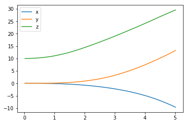

```python
import matplotlib.pyplot as plt
%matplotlib inline

plt.plot(results['time'], results['x'], label='x')
plt.plot(results['time'], results['y'], label='y')
plt.plot(results['time'], results['z'], label='z')
plt.legend()
_ = plt.ylim()
```

The next code cell visualizes the velocity of the quadcopter.

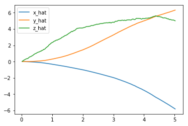

```python
plt.plot(results['time'], results['x_velocity'], label='x_hat')
plt.plot(results['time'], results['y_velocity'], label='y_hat')
plt.plot(results['time'], results['z_velocity'], label='z_hat')
plt.legend()
_ = plt.ylim()
```

Next, you can plot the Euler angles (the rotation of the quadcopter over the $x$-, $y$-, and $z$-axes),

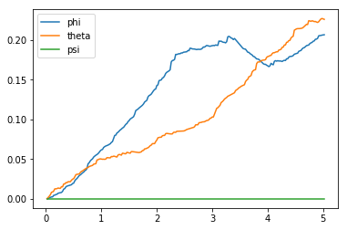

```python
plt.plot(results['time'], results['phi'], label='phi')
plt.plot(results['time'], results['theta'], label='theta')
plt.plot(results['time'], results['psi'], label='psi')
plt.legend()
_ = plt.ylim()
```

before plotting the velocities (in radians per second) corresponding to each of the Euler angles.

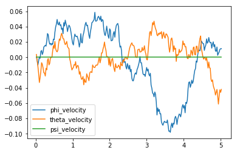

```python
plt.plot(results['time'], results['phi_velocity'], label='phi_velocity')
plt.plot(results['time'], results['theta_velocity'], label='theta_velocity')
plt.plot(results['time'], results['psi_velocity'], label='psi_velocity')
plt.legend()
_ = plt.ylim()
```

Finally, you can use the code cell below to print the agent's choice of actions.

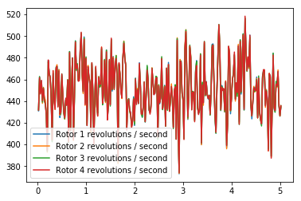

```python
plt.plot(results['time'], results['rotor_speed1'], label='Rotor 1 revolutions / second')
plt.plot(results['time'], results['rotor_speed2'], label='Rotor 2 revolutions / second')
plt.plot(results['time'], results['rotor_speed3'], label='Rotor 3 revolutions / second')
plt.plot(results['time'], results['rotor_speed4'], label='Rotor 4 revolutions / second')
plt.legend()
_ = plt.ylim()
```

When specifying a task, you will derive the environment state from the simulator. Run the code cell below to print the values of the following variables at the end of the simulation:

- `task.sim.pose` (the position of the quadcopter in ($x,y,z$) dimensions and the Euler angles),
- `task.sim.v` (the velocity of the quadcopter in ($x,y,z$) dimensions), and
- `task.sim.angular_v` (radians/second for each of the three Euler angles).

```python
# the pose, velocity, and angular velocity of the quadcopter at the end of the episode
print(task.sim.pose)
print(task.sim.v)
print(task.sim.angular_v)
```

```
[ -9.63375621  13.21626842  29.54935058   0.20650682   0.22586053   0.        ]
[-5.80905666  6.31483187  5.00700473]
[ 0.01110317 -0.04202734  0.        ]
```

In the sample task in `task.py`, we use the 6-dimensional pose of the quadcopter to construct the state of the environment at each timestep. However, when amending the task for your purposes, you are welcome to expand the size of the state vector by including the velocity information. You can use any combination of the pose, velocity, and angular velocity - feel free to tinker here, and construct the state to suit your task.

## The Task

A sample task has been provided for you in `task.py`. Open this file in a new window now.

The `__init__()` method is used to initialize several variables that are needed to specify the task.

- The simulator is initialized as an instance of the `PhysicsSim` class (from `physics_sim.py`).
- Inspired by the methodology in the original DDPG paper, we make use of action repeats. For each timestep of the agent, we step the simulation `action_repeats` timesteps. If you are not familiar with action repeats, please read the **Results** section in [the DDPG paper](https://arxiv.org/abs/1509.02971).
- We set the number of elements in the state vector. For the sample task, we only work with the 6-dimensional pose information. To set the size of the state (`state_size`), we must take action repeats into account.
- The environment will always have a 4-dimensional action space, with one entry for each rotor (`action_size=4`). You can set the minimum (`action_low`) and maximum (`action_high`) values of each entry here.
- The sample task in this provided file is for the agent to reach a target position. We specify that target position as a variable.

The `reset()` method resets the simulator. The agent should call this method every time the episode ends. You can see an example of this in the code cell below.

The `step()` method is perhaps the most important. It accepts the agent's choice of action `rotor_speeds`, which is used to prepare the next state to pass on to the agent. Then, the reward is computed from `get_reward()`. The episode is considered done if the time limit has been exceeded, or the quadcopter has travelled outside of the bounds of the simulation.

In the next section, you will learn how to test the performance of an agent on this task.

## The Agent

The sample agent given in `agents/policy_search.py` uses a very simplistic linear policy to directly compute the action vector as a dot product of the state vector and a matrix of weights. Then, it randomly perturbs the parameters by adding some Gaussian noise, to produce a different policy. Based on the average reward obtained in each episode (`score`), it keeps track of the best set of parameters found so far, how the score is changing, and accordingly tweaks a scaling factor to widen or tighten the noise.

Run the code cell below to see how the agent performs on the sample task.

```python
import sys
import pandas as pd
import numpy as np
from agents.policy_search import PolicySearch_Agent
from task import Task

num_episodes = 1000
target_pos = np.array([0., 0., 10.])
task = Task(target_pos=target_pos)
agent = PolicySearch_Agent(task)

for i_episode in range(1, num_episodes+1):
    state = agent.reset_episode() # start a new episode
    while True:
        action = agent.act(state)
        next_state, reward, done = task.step(action)
        agent.step(reward, done)
        state = next_state
        if done:
            print("\rEpisode = {:4d}, score = {:7.3f} (best = {:7.3f}), noise_scale = {}".format(
                i_episode, agent.score, agent.best_score, agent.noise_scale), end="")  # [debug]
            break
    sys.stdout.flush()
```

```
Episode = 1000, score =  -0.158 (best =  -0.088), noise_scale = 3.25
```

This agent should perform very poorly on this task. And that's where you come in!

## Define the Task, Design the Agent, and Train Your Agent!

Amend `task.py` to specify a task of your choosing. If you're unsure what kind of task to specify, you may like to teach your quadcopter to takeoff, hover in place, land softly, or reach a target pose.

After specifying your task, use the sample agent in `agents/policy_search.py` as a template to define your own agent in `agents/agent.py`. You can borrow whatever you need from the sample agent, including ideas on how you might modularize your code (using helper methods like `act()`, `learn()`, `reset_episode()`, etc.).

Note that it is **highly unlikely** that the first agent and task that you specify will learn well. You will likely have to tweak various hyperparameters and the reward function for your task until you arrive at reasonably good behavior.

As you develop your agent, it's important to keep an eye on how it's performing. Use the code above as inspiration to build in a mechanism to log/save the total rewards obtained in each episode to file. If the episode rewards are gradually increasing, this is an indication that your agent is learning.

```python
## TODO: Train hover task.
import numpy as np
import sys
import pandas as pd
from agents.ddpg import DDPGAgent
from tasks.hover_task import HoverTask


num_episodes = 2000
task = HoverTask()
agent = DDPGAgent(task)
scores = []
rewards = []
flight_data = {}

for i_episode in range(1, num_episodes+1):
    state = agent.reset_episode() # start a new episode
    while True:
        action = agent.act(state)
        next_state, reward, done = task.step(action)
        agent.step(action, reward, next_state, done)
        state = next_state
        if done:
            scores.append(agent.score)
            rewards.append(agent.total_reward)
            if i_episode % 50 == 0:
                flight_data[i_episode] = agent.stats
            print("\rEpisode = {:4d}, mean score = {:7.3f}  (best mean score = {:7.3f}) ".format(
                i_episode, agent.score, agent.best_score), end="")  # [debug]
            break
    sys.stdout.flush()
```

```
Episode = 2000, mean score =   0.877  (best mean score =   0.884)
```

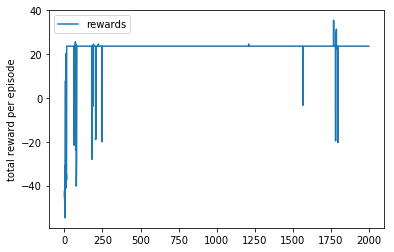

```python
import matplotlib.pyplot as plt
%matplotlib inline

plt.plot(range(len(rewards)), rewards, label='rewards')
plt.ylabel('total reward per episode')
plt.legend()
_ = plt.ylim()
```

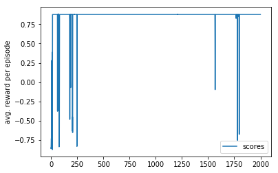

```python
import matplotlib.pyplot as plt
%matplotlib inline

plt.plot(range(len(scores)), scores, label='scores')
plt.ylabel('avg. reward per episode')
plt.legend()
_ = plt.ylim()
```

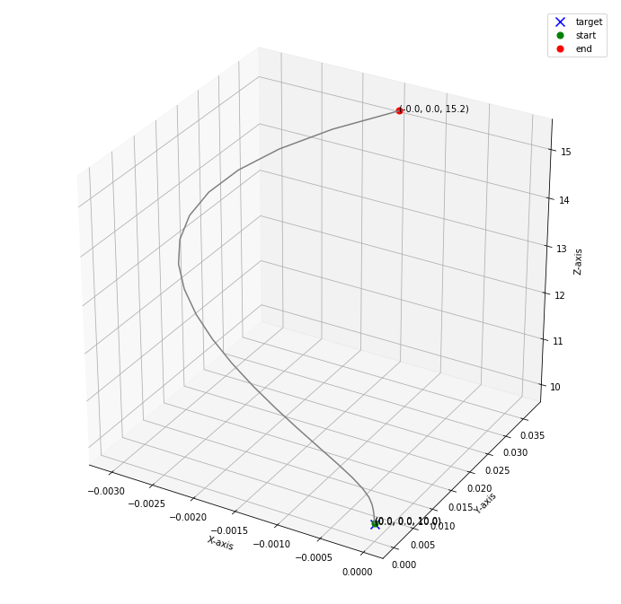

```python
%matplotlib inline
from plot import plot_flight, plot_point

plot_flight(agent.stats, task.target_pos, figsize=(12,12))
```

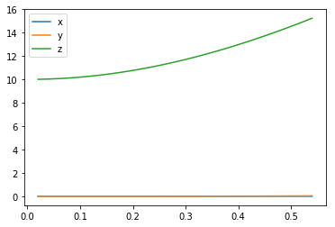

```python
import matplotlib.pyplot as plt
%matplotlib inline

plt.plot(agent.stats['time'], agent.stats['x'], label='x')
plt.plot(agent.stats['time'], agent.stats['y'], label='y')
plt.plot(agent.stats['time'], agent.stats['z'], label='z')
plt.legend()
_ = plt.ylim()
```

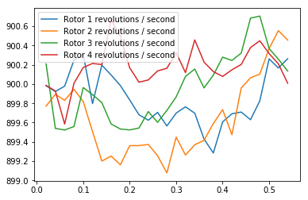

```python
plt.plot(agent.stats['time'], agent.stats['rotor_speed1'], label='Rotor 1 revolutions / second')
plt.plot(agent.stats['time'], agent.stats['rotor_speed2'], label='Rotor 2 revolutions / second')
plt.plot(agent.stats['time'], agent.stats['rotor_speed3'], label='Rotor 3 revolutions / second')
plt.plot(agent.stats['time'], agent.stats['rotor_speed4'], label='Rotor 4 revolutions / second')
plt.legend()
_ = plt.ylim()
```

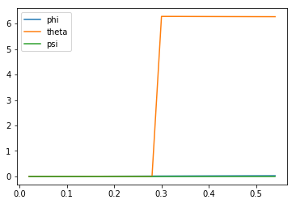

```python
plt.plot(agent.stats['time'], agent.stats['phi'], label='phi')
plt.plot(agent.stats['time'], agent.stats['theta'], label='theta')
plt.plot(agent.stats['time'], agent.stats['psi'], label='psi')
plt.legend()
_ = plt.ylim()
```

```python
## TODO: Train takeoff task
import numpy as np
import sys
import pandas as pd
from agents.ddpg import DDPGAgent
from tasks.takeoff_task import TakeoffTask


num_episodes = 2000
task = TakeoffTask()
agent = DDPGAgent(task)
scores = []
flight_data = {}

for i_episode in range(1, num_episodes+1):
    state = agent.reset_episode() # start a new episode
    while True:
        action = agent.act(state)
        next_state, reward, done = task.step(action)
        agent.step(action, reward, next_state, done)
        state = next_state
        if done:
            scores.append(agent.score)
            if i_episode % 50 == 0:
                flight_data[i_episode]= agent.stats
            print("\rEpisode = {:4d}, mean score = {:7.3f}  (best mean score = {:7.3f}) ".format(
                i_episode, agent.score, agent.best_score), end="")  # [debug]
            break
    sys.stdout.flush()
```

```
Episode =  890, mean score =  -0.990  (best mean score =   0.037)
```

[output not shown]

[output cut: 18 more lines]

[output not shown]

## Plot the Rewards

Once you are satisfied with your performance, plot the episode rewards, either from a single run, or averaged over multiple runs.

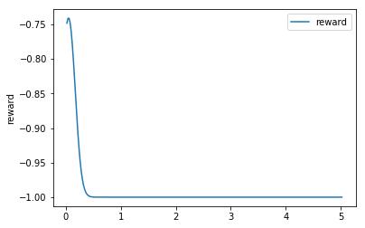

```python
import matplotlib.pyplot as plt
%matplotlib inline

# Testing the last episode that I ran. Episode #850
# This shows that I have more fine tuning to do with the reward function.
# The reward function is not getting better, yet the network found that it's not getting worse per second
# The angular velocity in Y is causing it to move in the X direction

# plt.plot(range(len(scores)), scores, label='scores')
plt.plot(flight_data[850]['time'],flight_data[850]['reward'], label='reward')
plt.ylabel('reward')
plt.legend()
_ = plt.ylim()
```

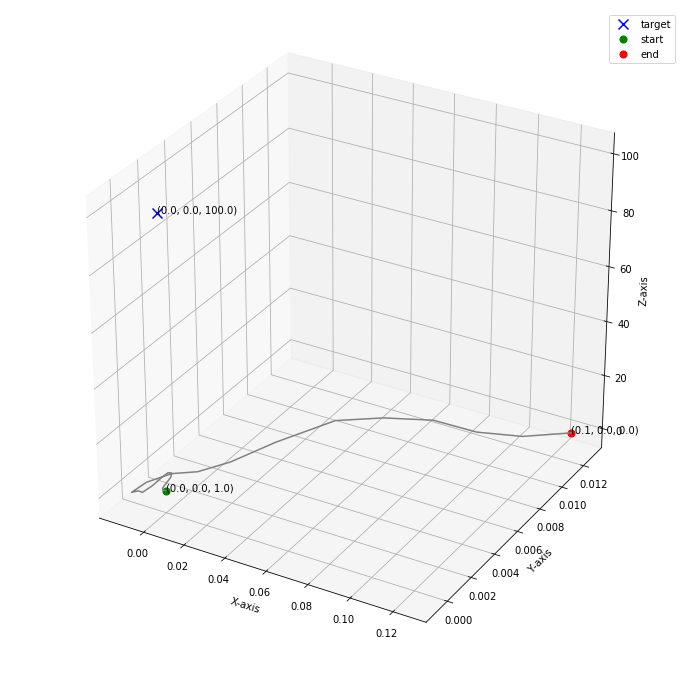

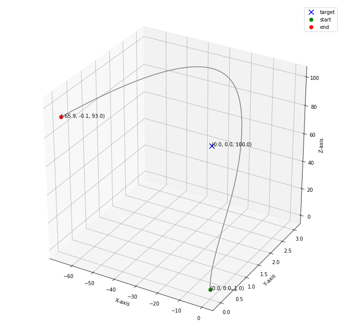

```python
%matplotlib inline
from plot import plot_flight, plot_point

# Here is a graph of the 50th episode and the 850 episode respectively

plot_flight(flight_data[50], task.target_pos, figsize=(12,12))
plot_flight(flight_data[850], task.target_pos, figsize=(12,12))
```

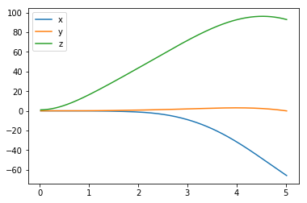

```python
import matplotlib.pyplot as plt
%matplotlib inline

plt.plot(flight_data[850]['time'], flight_data[850]['x'], label='x')
plt.plot(flight_data[850]['time'], flight_data[850]['y'], label='y')
plt.plot(flight_data[850]['time'], flight_data[850]['z'], label='z')
plt.legend()
_ = plt.ylim()
```

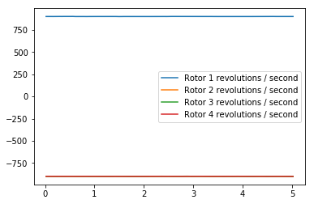

```python
plt.plot(flight_data[850]['time'], flight_data[850]['rotor_speed1'], label='Rotor 1 revolutions / second')
plt.plot(flight_data[850]['time'], flight_data[850]['rotor_speed2'], label='Rotor 2 revolutions / second')
plt.plot(flight_data[850]['time'], flight_data[850]['rotor_speed3'], label='Rotor 3 revolutions / second')
plt.plot(flight_data[850]['time'], flight_data[850]['rotor_speed4'], label='Rotor 4 revolutions / second')
plt.legend()
_ = plt.ylim()
```

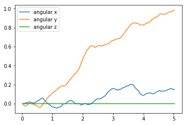

```python
plt.plot(flight_data[850]['time'], flight_data[850]['angular_x'], label='angular x')
plt.plot(flight_data[850]['time'], flight_data[850]['angular_y'], label='angular y')
plt.plot(flight_data[850]['time'], flight_data[850]['angular_z'], label='angular z')
plt.legend()
_ = plt.ylim()
```

## Reflections

**Question 1**: Describe the task that you specified in `task.py`. How did you design the reward function?

**Answer**:

**All these are still a work in progress...**

I tried both the hover task and the takeoff task. The reward function is the nexus of a great reinforcement learning task. I have found that the DDPG will exploit the reward function, so you have to be very careful with your design of the reward function.

Just as I describe in paragraph 4 of question 4, I found that for the hover task I used a reward function that penalized the absolute disance from the start to the target position. I discovered that with the hovering task, early exiting when the absolute distance is greater than ~5.0 in all directions is a good choice to terminate. Otherwise you will be stuck waiting for the "runtime" of the episode to complete for what seems to be pointless rewards.

For the takeoff task, I am currently using total distance from its starting point as its negative reward. This is super simple and needs to be normalized and experimented with. As it moves closer to its target position, I am reducing the negative penalty. I need to devise a better reward system as the reward seems to plateau at -1.0. The angular velocity in Y is causing it to move in the X direction, so I'm going to toy around with an alternative reward.

**Question 2**: Discuss your agent briefly, using the following questions as a guide:

- What learning algorithm(s) did you try? What worked best for you?
- What was your final choice of hyperparameters (such as $\alpha$, $\gamma$, $\epsilon$, etc.)?
- What neural network architecture did you use (if any)? Specify layers, sizes, activation functions, etc.

**Answer**:

Reinforcement learning, to me, is by far the most interesting and challenging subject in this course. The algorithm that I implemented is a actor-critic model-free DDPG, Deep Deterministic Policy Gradients, since it is a great fit for continuous values and high dimensional action spaces. Also, the sample code from Udacity was a great start for implementing an actor-critic DDPG in Keras.

My **current** neural network architecture consists of ...

##### Actor ( relu activation between hidden layers / batch normalization for crazy values / Glorot uniform for kernel initialization)

[output not shown]

##### Critic ( relu activation between hidden layers / batch normalization for crazy values / Glorot uniform for kernel initialization)

```
states:
{state_size} input layer
Dense 32 hidden layer
Dense 32 hidden layer
Dense 64 hidden layer
{action_size} output layer using sigmoid activation

actions:
{actions_size} input layer
Dense 32 hidden layer
Dense 32 hidden layer
Dense 64 hidden layer
{action_size} output layer using sigmoid activation

merge layers states and actions

Adam Optimization with MSE loss
```

For the hyperparameters I followed this paper https://arxiv.org/pdf/1509.02971.pdf.

```
Alpha: 0.99
Tau: 0.001
Actor learning rate: default since using ADAM
Critic learning rate: default since using ADAM
```

**References**: [Glorot inialization](http://proceedings.mlr.press/v9/glorot10a/glorot10a.pdf)

**Question 3**: Using the episode rewards plot, discuss how the agent learned over time.

- Was it an easy task to learn or hard?
- Was there a gradual learning curve, or an aha moment?
- How good was the final performance of the agent? (e.g. mean rewards over the last 10 episodes)

**Answer**:

This task was very tedious and hard to figure out. It took a lot of experimentation with different types of reward functions and hyperparameters before I could get it to somewhat learn. I think the breakthrough happened when I looked around at reference implementations of DDPG and found their continous control implementations used "tanh" as their action output layer, which I elaborate on for question 4. The final performance of the agent is ok, not super great, but that's due to my reward function, which is key, I believe.

**Here are some things that could improve upon the vanilla DDPG model**:

- [Actor Advantage Critic (A2C) model](https://hackernoon.com/intuitive-rl-intro-to-advantage-actor-critic-a2c-4ff545978752)
- [Prioritized Experience Replay](https://arxiv.org/pdf/1511.05952.pdf)

**Question 4**: Briefly summarize your experience working on this project. You can use the following prompts for ideas.

- What was the hardest part of the project? (e.g. getting started, plotting, specifying the task, etc.)
- Did you find anything interesting in how the quadcopter or your agent behaved?

**Answer**:

The hardest part of this project was figuring out where to start. Reinforcement learning is a cutting edge topic and constantly evolving. I believe that I watched every Udacity video in this final project at least 3 times before the ideas started to sink in. I had to read a lot of Richard Sutton's [Reinforcement Learning Book](https://s3-us-west-1.amazonaws.com/udacity-dlnfd/suttonbookdraft2018jan1.pdf), however it was still hard to gain intuition on certain concepts. David Silver's, from DeepMind, [reinforcement learning lecture series](https://www.youtube.com/watch?v=2pWv7GOvuf0&list=PLqYmG7hTraZDM-OYHWgPebj2MfCFzFObQ) really helped me out a lot.

When I was curious as to whether I was the only one making little progress on this final project, I jumped on the Udacity forums and noticed that a lot of students were having issues with this project. That was kind of comforting, but some of the students suggestions were to reduce the action space for particular tasks. For example, in the takeoff task you could reduce the action space to a single speed value for going up. Some students even set their min speed and max speed to the same value. At first I thought this was kind of a hack, shouldn't deep reinforcement learning figure out how to control each rotor in order to maximize reward? So, I stayed the course with 4 action outputs, one for each rotor. That led me to my aha moment below...

At one point I was really stuck and tweaked the actor's neural network output layer. I changed the output layer from sigmoid activation, 0.0 to 1.0, to tanh activation, -1.0 to 1.0, and the network drastically improved, yet it would produce rotor speed values between -900 and 900. I'm not 100% sure how the PhysicsSim works, but with quadrotor designs, usually each rotor spins CCW with the adjacent rotor spinning in a CW direction. So having negative rotor speeds should be "ok", depending on the torque per each rotor. Actually, this caused the network to converge much faster however the quadcopter would spin like crazy in the beginning, yet find the optimal'ish policy for takeoff and hovering. In order to stop the quadcopter from spinning, I had to come up with a reward function that penalized too much rotation. I think my key takeaway from this project is that not only are your hyperparameters so important with reinforcement learning, but your reward function is critical too. The Udacity "troubleshooting" notes were crucial for figuring out a good reward function and fixing the exploding gradients problem. There are lots and lots of things to experiment with.

The reward function is super interesting. I find myself constantly tweaking the reward functions for both takeoff and hovering. I added stats that track each every 50th epsiode's flight data. It's super interesting to me how DDPG learns how to optimize for a certain reward function. The network learns new and interesting ways to exploit a poorly written reward function. For example, I discovered that with the hovering task early exiting when the absolute distance is greater than ~5.0 in all directions is a good choice to terminate. Otherwise you're waiting around for the "runtime" of the episode to complete for what seems to be pointless rewards.